# Testing the hierarchical reserving models on the simulation engine proposed by Wang and Wuthrich

Christophe Nozaradan

October 2022

## Introduction

This document implements hierarchical reserving models based on the extended hirem package. The input data is generated using the simulation engine from Wang and Wuthrich, described the following paper:

Wang, Melantha and Wuthrich, Mario V., Individual Claims Generator for Claims Reserving Studies: Data Simulation.R (June 3, 2022). Available at SSRN: https://ssrn.com/abstract=4127073 or http://dx.doi.org/10.2139/ssrn.4127073

## Simulating the portfolio

We evaluate the predictive performance of our hierarchical reserving model (hierarchical GLM, hierarchical GBM, hierarchical XGB and hierarchical DNN) on one portfolio simulated along the extreme event scenario. We compare the results with the ones obtained using an aggregate reserving model, namely the classical chain ladder model.

First, we load the required packages.

```r
require(SynthETIC)  # 1.0.0 or higher needed
require(plyr)
require(dplyr)
require(locfit)
require(actuar)
require(tidyr)
require(lubridate)
require(tidyverse)
require(xgboost)
require(Matrix)
require(tidyverse)
require(data.table)
require(ggplot2)
require(recipes)
require(tensorflow)
require(keras)
#install.packages('devtools')
#devtools::install_github('cnoza/hirem')
require(hirem)
```

We simulate one portfolio using the simulation engine from Wang and Wuthrich.

The seed number is:

```r
cat(sprintf("%s", seed))
```

```
## 1
```

```r
ref_claim <- 1          # currency is 1
time_unit <- 1/12       # we consider monthly claims development
set_parameters(ref_claim=ref_claim, time_unit=time_unit)

years <- 17               # number of occurrence years
I <- years/time_unit      # number of development periods

source("./wang-wuthrich/Tools/functions simulation.R")
dest_path <- "" # plot to be saved in ...

#####################################################################
#### generate claim data
#####################################################################

# generate individual claims: may take 60 seconds
claims_list <- data.generation(seed=seed, future_info=F)

# We unset the seed
set.seed(NULL)

# save individual output for easier access
claims <- claims_list[[1]]
claims <- claims %>% filter(Status == 'Closed')

paid <- claims_list[[2]]

# We now build a reserving dataset compatible with hirem

d0 <- merge(paid, claims, by="Id") %>%
  arrange(Id, EventId)

d0 <- d0 %>%
  mutate(calendar.year = floor(EventMonth/12)+1,
         rep.year = floor(RepMonth/12)+1,
         dev.year = calendar.year - rep.year + 1,
         size = Paid) %>%
  select(Id, dev.year, size)

d1 <- expand.grid(Id = unique(d0$Id),
                  dev.year = 1:max(d0$dev.year),
                  size = 0)

d2 <- union_all(d0,d1)

d3 <- d2 %>%
    group_by(Id, dev.year) %>%
    dplyr::summarise(total = sum(size))
colnames(d3) <- c('Id','dev.year', 'size')

d4 <- merge(d3, claims, by="Id", all.x = T)

reserving_data <- d4 %>%
  mutate(rep.year = floor(RepMonth/12)+1,
         calendar.year = dev.year + rep.year - 1,
         settlement.year = floor(SetMonth/12)+1,
         payment = as.integer(size>0),
         recovery = as.integer(size<0),
         size.pay = ifelse(size>0,size,0),
         size.recov = ifelse(size<0, -size, 0),
         occ.month = AccMonth,
         occ.date = AccDate,
         occ.weekday = factor(AccWeekday),
         rep.date = RepDate,
         age = Age,
         age.fact = factor(Age),
         settlement = as.integer(calendar.year >= settlement.year),
         open = as.integer(ifelse(calendar.year==settlement.year,1,1-settlement)),
         type = factor(Type),
         rep.month = factor(month(ymd(RepDate)))) %>%
  select(-CumPaid, -Type, -Ultimate, -Status, -PayCount, -AccMonth, -AccDate, -Age, -AccWeekday, -RepDate, RepMonth) %>%
  arrange(Id, dev.year)

reserving_data <- reserving_data %>% filter(rep.year <= 10 & dev.year <= 10)

ultimate <- reserving_data %>%
  dplyr::group_by(Id) %>%
  dplyr::summarise(total.size.pay = sum(size.pay))

reserving_data <- merge(reserving_data, ultimate, by="Id", all.x=T)

reserving_data <- reserving_data %>%
  mutate(p.size.recov = ifelse(size<0, -size/total.size.pay, 0),
         q.size.recov = ifelse(size<0, p.size.recov/(1-p.size.recov), 0))

reserving_data$dev.year.fact <- factor(reserving_data$dev.year, levels = 1:max(reserving_data$dev.year))
reserving_data$rep.year.fact <- factor(reserving_data$rep.year, levels = 1:max(reserving_data$rep.year))

reserving_data$monthDev12 <- as.character(reserving_data$rep.month)
reserving_data$monthDev12[reserving_data$dev.year > 3] <- 'dev.year.over.3'
reserving_data$devYearMonth <- factor(paste(reserving_data$dev.year, reserving_data$monthDev12, sep = '-'))

str(reserving_data)
```

```
## 'data.frame':    1111820 obs. of  31 variables:
##  $ Id             : int  1 1 1 1 1 1 1 1 1 1 ...
##  $ dev.year       : num  1 2 3 4 5 6 7 8 9 10 ...
##  $ size           : num  3282 3821 0 0 0 ...
##  $ RepMonth       : num  1 1 1 1 1 1 1 1 1 1 ...
##  $ RepDelDays     : int  1 1 1 1 1 1 1 1 1 1 ...
##  $ SetMonth       : num  17 17 17 17 17 17 17 17 17 17 ...
##  $ SetDelMonths   : num  16 16 16 16 16 16 16 16 16 16 ...
##  $ rep.year       : num  1 1 1 1 1 1 1 1 1 1 ...
##  $ calendar.year  : num  1 2 3 4 5 6 7 8 9 10 ...
##  $ settlement.year: num  2 2 2 2 2 2 2 2 2 2 ...
##  $ payment        : int  1 1 0 0 0 0 0 0 0 0 ...
##  $ recovery       : int  0 0 0 0 0 0 0 0 0 0 ...
##  $ size.pay       : num  3282 3821 0 0 0 ...
##  $ size.recov     : num  0 0 0 0 0 0 0 0 0 0 ...
```

[output cut: 17 more lines]

```r
# Observed and prediction data set
observed_data   <- reserving_data %>% filter(calendar.year <= 10)
prediction_data <- reserving_data %>% filter(calendar.year > 10)
```

## Calibration of the hierarhical reserving models

We first define the weights used in the calibration of the hierarchical reserving model. The purpose of these weights is to replicate the development year distribution from the prediction data set to the observed data set (training data set). Hence, more weight is assigned to claims observations in later development years since reporting. We give a very small weight to the claims observations in the first development year since reporting because the prediction data set does not contain observations for this development year. More details are provided in Creveceour, Antonio, and Robben (2021)

```r
# Calculating the weights
reported_claims <- observed_data %>%
  dplyr::filter(dev.year == 1) %>%
  group_by(rep.year) %>%
  dplyr::summarise(count = n()) %>%
  pull(count)

denominator <- tail(rev(cumsum(reported_claims)), -1)
numerator <- head(cumsum(rev(reported_claims)), -1)
weight <- c(10^(-6), numerator / denominator)

names(weight) <- paste0('dev.year',1:10)
weight
```

```
##  dev.year1  dev.year2  dev.year3  dev.year4  dev.year5  dev.year6  dev.year7  dev.year8  dev.year9 dev.year10
##  0.0000010  0.1157250  0.2616254  0.4548048  0.7191941  1.1004685  1.6901691  2.7632683  5.2860858 15.9588164
```

### Hierarchical GLM

We define the model specifications of each layer. We only train the reserving model on the claim updates that are still open at the beginning of each year and are observed on the evaluation date (`calendar.year <= 10`).

```r
# Model specifications hierarchical GLM
model_glm  <- hirem(reserving_data) %>%
  split_data(observed = function(df) df %>% filter(calendar.year <= 10, open == 1)) %>%
  layer_glm(name = 'settlement', 'family' = binomial(link = cloglog)) %>%
  layer_glm(name = 'payment', 'family' = binomial(link = logit)) %>%
  layer_glm(name = 'recovery', 'family' = binomial(link = logit)) %>%
  layer_glm(name = 'size.pay', 'family' = Gamma(link = 'log'),
            filter = function(x){x$payment == 1}) %>%
  layer_glm(name = 'q.size.recov', 'family' = Gamma(link = 'log'),
            filter = function(x){x$recovery == 1})
```

```r
# Covariate selection function
covariate_selection <- function(response_variable, all_covariates, family, data, weight, minimize="deviance") {
  aic_sav <- NULL
  deviance_sav <- NULL
  aic <- c()
  deviance <- c()
  formula_resp_list <- c()
  step <- c()
  i = 1
  covariate_sav_list <- c()
  weights.vec <- weight[data[['dev.year']]]

  while(length(all_covariates) > 0) {
    covariate_sav <- NULL
    for(covariate in all_covariates) {
      cov_list <- append(covariate_sav_list, covariate)
      formula_resp <- as.formula(paste0(response_variable, ' ~ ',paste0(cov_list, collapse = ' + ')))
      m_glm <- glm(formula_resp , family = family, data = data, weights = weights.vec)
      aic <- append(aic, m_glm$aic)
      deviance <- append(deviance, m_glm$deviance)
      formula_resp_list <- append(formula_resp_list, formula_resp)
      step = append(step,i)

      if(is.null(aic_sav)) aic_sav = m_glm$aic + 1
      if(is.null(deviance_sav)) deviance_sav = m_glm$deviance + 1

      if( (m_glm$deviance < deviance_sav & minimize == "deviance")
          | (m_glm$aic < aic_sav & minimize == "aic")) {
        #formula_resp_sav <- formula_resp
        covariate_sav <- covariate
        aic_sav <- m_glm$aic
        deviance_sav <- m_glm$deviance
      }
    }
    if(!is.null(covariate_sav)) {
      covariate_sav_list <- append(covariate_sav_list, covariate_sav)
      all_covariates <- all_covariates[all_covariates != covariate_sav]
      i=i+1
    } else all_covariates <- NULL

  }

  if(minimize=="deviance")
    res.tab <- data.frame(step = step,
                          m_formula = as.character(formula_resp_list),
                          aic = aic,
                          deviance = deviance) %>% arrange(deviance)
  else
    res.tab <- data.frame(step = step,
                          m_formula = as.character(formula_resp_list),
                          aic = aic, deviance = deviance) %>% arrange(aic)

  return(res.tab)

}

# Covariate selection for settlement layer
all_covariates <- c('type', 'dev.year.fact', 'rep.month', 'devYearMonth', 'age.fact')
family.settle <- model_glm$layers$settlement$method_options
res.tab.settle <- covariate_selection('settlement', all_covariates, family.settle,
                                      model_glm$data_observed, weight, minimize='deviance')
print(res.tab.settle)
```

```
##    step                                                m_formula      aic deviance
## 1     3                 settlement ~ type + age.fact + rep.month 4254.665 28374.49
## 2     2                             settlement ~ type + age.fact 4226.591 28398.23
## 3     2                            settlement ~ type + rep.month 4160.918 28432.09
## 4     1                                        settlement ~ type 4133.623 28455.08
## 5     1                                    settlement ~ age.fact 4183.489 28919.60
## 6     1                                   settlement ~ rep.month 4116.534 28939.13
## 7     4  settlement ~ type + age.fact + rep.month + devYearMonth 5235.254 28951.09
## 8     3              settlement ~ type + age.fact + devYearMonth 5223.235 28959.58
## 9     4 settlement ~ type + age.fact + rep.month + dev.year.fact 5180.080 28975.66
## 10    3             settlement ~ type + age.fact + dev.year.fact 5156.353 29011.47
## 11    2                         settlement ~ type + devYearMonth 5143.804 29053.15
## 12    2                        settlement ~ type + dev.year.fact 5076.946 29102.13
## 13    1                                settlement ~ devYearMonth 5195.795 29786.08
## 14    1                               settlement ~ dev.year.fact 5129.795 29819.95
```

```r
# Covariate selection for payment layer
all_covariates <- c('settlement', 'type', 'dev.year.fact', 'rep.month', 'devYearMonth', 'age.fact')
family.pay <- model_glm$layers$payment$method_options
res.tab.pay <- covariate_selection('payment',all_covariates, family.pay,
                                   model_glm$data_observed, weight, minimize='deviance')
print(res.tab.pay)
```

```
##    step                                                                         m_formula      aic deviance
## 1     5                 payment ~ settlement + devYearMonth + type + age.fact + rep.month 2916.082 14886.62
## 2     6 payment ~ settlement + devYearMonth + type + age.fact + rep.month + dev.year.fact 2916.082 14886.62
## 3     4                             payment ~ settlement + devYearMonth + type + age.fact 2894.807 14894.38
## 4     5             payment ~ settlement + devYearMonth + type + age.fact + dev.year.fact 2894.807 14894.38
## 5     4                            payment ~ settlement + devYearMonth + type + rep.month 2830.543 14916.18
## 6     3                                        payment ~ settlement + devYearMonth + type 2809.068 14923.42
## 7     4                        payment ~ settlement + devYearMonth + type + dev.year.fact 2809.068 14923.42
## 8     3                                    payment ~ settlement + devYearMonth + age.fact 2869.903 15130.14
## 9     3                                   payment ~ settlement + devYearMonth + rep.month 2807.125 15142.01
## 10    2                                               payment ~ settlement + devYearMonth 2785.384 15146.82
## 11    3                               payment ~ settlement + devYearMonth + dev.year.fact 2785.384 15146.82
## 12    2                                              payment ~ settlement + dev.year.fact 2719.216 15185.77
## 13    2                                                       payment ~ settlement + type 3002.190 15389.48
## 14    2                                                   payment ~ settlement + age.fact 3006.157 15466.17
## 15    2                                                  payment ~ settlement + rep.month 2944.402 15479.42
## 16    1                                                              payment ~ settlement 2925.501 15483.95
## 17    1                                                            payment ~ devYearMonth 3778.676 22597.70
## 18    1                                                           payment ~ dev.year.fact 3712.676 22654.15
## 19    1                                                                    payment ~ type 3756.311 22721.30
## 20    1                                                                payment ~ age.fact 3848.400 22723.83
## 21    1                                                               payment ~ rep.month 3792.106 22734.08
```

```r
# Covariate selection for recovery layer
all_covariates <- c('settlement', 'type', 'dev.year.fact', 'rep.month', 'devYearMonth', 'age.fact')
family.recov <- model_glm$layers$recovery$method_options
res.tab.recov <- covariate_selection('recovery',all_covariates, family.recov, model_glm$data_observed, weight, minimize='deviance')
print(res.tab.recov)
```

```
##    step                                                                          m_formula      aic deviance
## 1     5                 recovery ~ devYearMonth + settlement + type + age.fact + rep.month 874.2804 2030.179
## 2     6 recovery ~ devYearMonth + settlement + type + age.fact + rep.month + dev.year.fact 874.2804 2030.179
## 3     4                             recovery ~ devYearMonth + settlement + type + age.fact 861.1205 2041.825
## 4     5             recovery ~ devYearMonth + settlement + type + age.fact + dev.year.fact 861.1205 2041.825
## 5     4                            recovery ~ devYearMonth + settlement + type + rep.month 798.3186 2046.599
## 6     3                                        recovery ~ devYearMonth + settlement + type 786.9050 2058.760
## 7     4                        recovery ~ devYearMonth + settlement + type + dev.year.fact 786.9050 2058.760
## 8     3                                    recovery ~ devYearMonth + settlement + age.fact 874.0732 2092.494
## 9     3                                   recovery ~ devYearMonth + settlement + rep.month 815.9317 2100.145
## 10    3                               recovery ~ devYearMonth + settlement + dev.year.fact 801.5756 2111.338
## 11    2                                               recovery ~ devYearMonth + settlement 801.5756 2111.338
## 12    2                                                     recovery ~ devYearMonth + type 817.8662 2131.667
## 13    2                                                 recovery ~ devYearMonth + age.fact 899.3167 2150.068
## 14    2                                                recovery ~ devYearMonth + rep.month 843.2913 2159.553
## 15    2                                            recovery ~ devYearMonth + dev.year.fact 827.3927 2169.627
## 16    1                                                            recovery ~ devYearMonth 827.3927 2169.627
## 17    1                                                           recovery ~ dev.year.fact 761.3927 2191.562
## 18    1                                                                    recovery ~ type 786.6639 2244.302
## 19    1                                                              recovery ~ settlement 797.9960 2252.017
## 20    1                                                                recovery ~ age.fact 901.2300 2305.115
## 21    1                                                               recovery ~ rep.month 848.1104 2305.698
```

```r
# Covariate selection for size.pay layer
all_covariates <- c('settlement', 'type', 'dev.year.fact', 'rep.month', 'devYearMonth', 'age.fact')
d_size_pay <- model_glm$data_observed %>% filter(payment == 1)
family.size.pay <- model_glm$layers$size.pay$method_options
res.tab.size.pay <- covariate_selection('size.pay', all_covariates, family.size.pay, d_size_pay, weight, minimize='deviance')
print(res.tab.size.pay)
```

```
##    step                                                                          m_formula      aic deviance
## 1     5                 size.pay ~ type + devYearMonth + age.fact + rep.month + settlement 343765.0 13680.43
## 2     6 size.pay ~ type + devYearMonth + age.fact + rep.month + settlement + dev.year.fact 343765.0 13680.43
## 3     4                              size.pay ~ type + devYearMonth + age.fact + rep.month 343802.6 13708.16
## 4     5              size.pay ~ type + devYearMonth + age.fact + rep.month + dev.year.fact 343802.6 13708.16
## 5     4                             size.pay ~ type + devYearMonth + age.fact + settlement 343801.5 13721.34
## 6     3                                          size.pay ~ type + devYearMonth + age.fact 343839.3 13749.22
## 7     4                          size.pay ~ type + devYearMonth + age.fact + dev.year.fact 343839.3 13749.22
## 8     3                                        size.pay ~ type + devYearMonth + settlement 344101.9 14000.05
## 9     3                                         size.pay ~ type + devYearMonth + rep.month 344125.7 14002.75
## 10    2                                                     size.pay ~ type + devYearMonth 344159.5 14042.61
## 11    3                                     size.pay ~ type + devYearMonth + dev.year.fact 344159.5 14042.61
## 12    2                                                    size.pay ~ type + dev.year.fact 344241.7 14148.88
## 13    2                                                         size.pay ~ type + age.fact 345087.8 14713.03
## 14    2                                                        size.pay ~ type + rep.month 345367.9 14977.58
## 15    2                                                       size.pay ~ type + settlement 345461.8 15064.15
## 16    1                                                                    size.pay ~ type 345465.9 15068.79
## 17    1                                                            size.pay ~ devYearMonth 351915.5 20676.83
## 18    1                                                           size.pay ~ dev.year.fact 352092.7 20922.92
## 19    1                                                              size.pay ~ settlement 354478.6 23493.15
## 20    1                                                               size.pay ~ rep.month 354585.3 23590.86
## 21    1                                                                size.pay ~ age.fact 354808.0 23761.40
```

```r
# Covariate selection for size.recov layer
all_covariates <- c('settlement', 'type', 'dev.year.fact', 'rep.month', 'devYearMonth', 'age.fact')
d_size_recov <- model_glm$data_observed %>% filter(recovery == 1)
family.size.recov <- model_glm$layers$q.size.recov$method_options
res.tab.size.recov <- covariate_selection('q.size.recov', all_covariates, family.size.recov, d_size_recov, weight, minimize='deviance')
print(res.tab.size.recov)
```

```
##    step                                                                              m_formula      aic  deviance
## 1     5                 q.size.recov ~ age.fact + devYearMonth + rep.month + settlement + type 386.2272  98.38969
## 2     6 q.size.recov ~ age.fact + devYearMonth + rep.month + settlement + type + dev.year.fact 386.2272  98.38969
## 3     4                        q.size.recov ~ age.fact + devYearMonth + rep.month + settlement 378.2310  99.28672
## 4     5        q.size.recov ~ age.fact + devYearMonth + rep.month + settlement + dev.year.fact 378.2310  99.28672
## 5     4                              q.size.recov ~ age.fact + devYearMonth + rep.month + type 389.2683 100.66093
## 6     3                                     q.size.recov ~ age.fact + devYearMonth + rep.month 381.3235 101.60080
## 7     4                     q.size.recov ~ age.fact + devYearMonth + rep.month + dev.year.fact 381.3235 101.60080
## 8     3                                    q.size.recov ~ age.fact + devYearMonth + settlement 363.0387 102.39140
## 9     3                                          q.size.recov ~ age.fact + devYearMonth + type 374.4354 103.97392
## 10    2                                                 q.size.recov ~ age.fact + devYearMonth 366.1635 104.78773
## 11    3                                 q.size.recov ~ age.fact + devYearMonth + dev.year.fact 366.1635 104.78773
## 12    2                                                q.size.recov ~ age.fact + dev.year.fact 328.2746 109.66865
## 13    2                                                   q.size.recov ~ age.fact + settlement 327.8083 115.49227
## 14    2                                                    q.size.recov ~ age.fact + rep.month 348.2330 115.71202
## 15    2                                                         q.size.recov ~ age.fact + type 336.3332 115.76394
## 16    1                                                                q.size.recov ~ age.fact 330.4135 117.89606
## 17    1                                                            q.size.recov ~ devYearMonth 327.6720 134.27189
## 18    1                                                               q.size.recov ~ rep.month 292.8366 137.36937
## 19    1                                                           q.size.recov ~ dev.year.fact 285.7329 137.91347
## 20    1                                                              q.size.recov ~ settlement 273.8823 138.00435
## 21    1                                                                    q.size.recov ~ type 284.7444 139.75610
```

Next, we provide the formulae for each layer, coming from the covariate selection procedure.

```r
# Formulae hierarchical GLM layers - model calibration
formula_settle_glm <- res.tab.settle$m_formula[[1]]
formula_pay_glm    <- res.tab.pay$m_formula[[1]]
formula_recov_glm    <- res.tab.recov$m_formula[[1]]
formula_size_pay_glm   <- res.tab.size.pay$m_formula[[1]]
formula_size_recov_glm    <- res.tab.size.recov$m_formula[[1]]
```

We fit the hierarchical GLM on the observed portfolio of simulated claims.

```r
# Fitting the hierarchical GLM
model_glm <- hirem::fit(model_glm,
                 weights = weight,
                 weight.var = 'dev.year',
                 balance.var = 'dev.year',
                 settlement = formula_settle_glm,
                 payment = formula_pay_glm,
                 recovery = formula_recov_glm,
                 size.pay = formula_size_pay_glm,
                 q.size.recov = formula_size_recov_glm)
```

```
## Fitting layer_glm for settlement...
## Fitting layer_glm for payment...
## Fitting layer_glm for recovery...
## Fitting layer_glm for size.pay...
## Fitting layer_glm for q.size.recov...
```

### Hierarchical GBM

We first define the model specifications of each layer. We only train the reserving model on the claim updates that are still open at the beginning of each year and are observed on the evaluation date (`calendar.year <= 10`). We tune some of the GBM parameters (number of trees, interaction depth and shrinkage) using a 5-fold cross validation approach (Creveceour, Antonio, and Robben 2021). We list here the obtained results from the tuning strategy in the paper. We further fix the `bag.fraction` to 0.75 and the minimum number of observecations each node (`n.minobsinnode`) to 100.

```r
# Results of hierarchical model calibration
gbm_param_settle <- list('n.trees' = 225, 'interaction.depth' = 1, 'shrinkage' = 0.05)
gbm_param_pay    <- list('n.trees' = 125, 'interaction.depth' = 3, 'shrinkage' = 0.05)
gbm_param_recov    <- list('n.trees' = 125, 'interaction.depth' = 3, 'shrinkage' = 0.05)
gbm_param_size_pay   <- list('n.trees' = 700, 'interaction.depth' = 1, 'shrinkage' = 0.05)
gbm_param_size_recov   <- list('n.trees' = 700, 'interaction.depth' = 1, 'shrinkage' = 0.05)

# Model specifications
model_gbm <- hirem(reserving_data) %>%
  split_data(observed = function(df) df %>% filter(calendar.year <= 10, open == 1)) %>%
  layer_gbm('settlement', distribution = 'bernoulli', bag.fraction = 0.75, n.minobsinnode = 100,
            n.trees = gbm_param_settle$n.trees, interaction.depth = gbm_param_settle$interaction.depth,
            shrinkage = gbm_param_settle$shrinkage, select_trees = 'last') %>%
  layer_gbm('payment', distribution = 'bernoulli', bag.fraction = 0.75, n.minobsinnode = 100,
            n.trees = gbm_param_pay$n.trees, interaction.depth = gbm_param_pay$interaction.depth,
            shrinkage = gbm_param_pay$shrinkage, select_trees = 'last') %>%
  layer_gbm('recovery', distribution = 'bernoulli', bag.fraction = 0.75, n.minobsinnode = 100,
            n.trees = gbm_param_recov$n.trees, interaction.depth = gbm_param_recov$interaction.depth,
            shrinkage = gbm_param_recov$shrinkage, select_trees = 'last') %>%
  layer_gbm('size.pay', distribution = 'gamma', bag.fraction = 0.75, n.minobsinnode = 100,
            n.trees = gbm_param_size_pay$n.trees, interaction.depth = gbm_param_size_pay$interaction.depth,
            shrinkage = gbm_param_size_pay$shrinkage, select_trees = 'last',
            filter = function(data){data$payment == 1}) %>%
  layer_gbm('q.size.recov', distribution = 'gamma', bag.fraction = 0.75, n.minobsinnode = 100,
            n.trees = gbm_param_size_recov$n.trees, interaction.depth = gbm_param_size_recov$interaction.depth,
            shrinkage = gbm_param_size_recov$shrinkage, select_trees = 'last',
            filter = function(data){data$recovery == 1})
```

We now fit the hierarchical GBM on the observed portfolio of simulated claims.

```r
# Covariates
covariates_gbm <- c('type', 'dev.year.fact', 'rep.month', 'rep.year.fact', 'age.fact', 'calendar.year')

# Fitting the hierarchical GBM
model_gbm <- hirem::fit(model_gbm,
                 weights = weight,
                 weight.var = 'dev.year',
                 balance.var = 'dev.year',
                 settlement = paste0('settlement ~ 1 + ', paste0(covariates_gbm, collapse = ' + ')),
                 payment = paste0('payment ~ 1 + ', paste0(c(covariates_gbm, 'settlement'), collapse = ' + ')),
                 recovery = paste0('recovery ~ 1 + ', paste0(c(covariates_gbm, 'settlement'), collapse = ' + ')),
                 size.pay = paste0('size.pay ~ 1 + ', paste0(c(covariates_gbm,'settlement'), collapse = ' + ')),
                 q.size.recov = paste0('q.size.recov ~ 1 + ', paste0(c(covariates_gbm,'settlement'), collapse = ' + ')))
```

```
## Fitting layer_gbm for settlement...
## Fitting layer_gbm for payment...
## Fitting layer_gbm for recovery...
## Fitting layer_gbm for size.pay...
## Fitting layer_gbm for q.size.recov...
```

### Hierarchical XGB

We first define the model specifications of each layer. We only train the reserving model on the claim updates that are still open at the beginning of each year and are observed on the evaluation date (`calendar.year <= 10`).

To tune the hyperparameters, one can activate a cross-validation by setting the `nfolds` parameter to the desired integer in the `layer_xgb` function. Optionally, one can provide a `hyper_grid` parameter or use a predefined one. The hyperparameters performing the best will then be retained automatically.

```r
# Results of hierarchical model calibration
xgb_param_settle       <- list('eta' =   .5, 'max_depth' = 3, 'nrounds' =  40, 'subsample' = 1)
xgb_param_pay          <- list('eta' =  .5, 'max_depth' = 3, 'nrounds' =  25, 'subsample' = 1)
xgb_param_recov        <- list('eta' =  .5, 'max_depth' = 3, 'nrounds' =  25, 'subsample' = 1)
xgb_param_size_pay     <- list('eta' = .05, 'max_depth' = 3, 'nrounds' = 800, 'subsample' = 1)
xgb_param_size_recov   <- list('eta' = .05, 'max_depth' = 3, 'nrounds' = 800, 'subsample' = 1)

# Model specifications
model_xgb <- hirem(reserving_data) %>%
  split_data(observed = function(df) df %>% filter(calendar.year <= 10, open == 1)) %>%
  layer_xgb('settlement', objective = 'binary:logistic', eval_metric = 'logloss', grow_policy = 'lossguide',
            eta = xgb_param_settle$eta, max_depth = xgb_param_settle$max_depth,
            nrounds = xgb_param_settle$nrounds, subsample = xgb_param_settle$subsample) %>%
  layer_xgb('payment', objective = 'binary:logistic', eval_metric = 'logloss', grow_policy = 'lossguide',
            eta = xgb_param_pay$eta, max_depth = xgb_param_pay$max_depth,
            nrounds = xgb_param_pay$nrounds, subsample = xgb_param_pay$subsample) %>%
  layer_xgb('recovery', objective = 'binary:logistic', eval_metric = 'logloss', grow_policy = 'lossguide',
            eta = xgb_param_recov$eta, max_depth = xgb_param_recov$max_depth,
            nrounds = xgb_param_recov$nrounds, subsample = xgb_param_recov$subsample) %>%
  layer_xgb('size.pay', objective = 'reg:gamma',
            eval_metric = 'gamma-deviance', grow_policy = 'lossguide',
            eta = xgb_param_size_pay$eta, max_depth = xgb_param_size_pay$max_depth,
            nrounds = xgb_param_size_pay$nrounds, subsample = xgb_param_size_pay$subsample,
            filter = function(data){data$payment == 1}) %>%
  layer_xgb('q.size.recov', objective = 'reg:gamma',
            eval_metric = 'gamma-deviance', grow_policy = 'lossguide',
            eta = xgb_param_size_recov$eta, max_depth = xgb_param_size_recov$max_depth,
            nrounds = xgb_param_size_recov$nrounds, subsample = xgb_param_size_recov$subsample,
            filter = function(data){data$recovery == 1})
```

We now fit the hierarchical XGB on the observed portfolio of simulated claims.

```r
# Covariates
covariates_xgb <- c('type', 'dev.year.fact', 'rep.month', 'rep.year.fact', 'age.fact', 'calendar.year')

# Fitting the hierarchical XGB
model_xgb <- hirem::fit(model_xgb,
                        weights = weight,
                        weight.var = 'dev.year',
                        balance.var = 'dev.year',
                        settlement = paste0('settlement ~ ', paste0(covariates_xgb, collapse = ' + ')),
                        payment = paste0('payment ~ ', paste0(c(covariates_xgb, 'settlement'), collapse = ' + ')),
                        recovery = paste0('recovery ~ ', paste0(c(covariates_xgb, 'settlement'), collapse = ' + ')),
                        size.pay = paste0('size.pay ~ ', paste0(c(covariates_xgb,'settlement'), collapse = ' + ')),
                        q.size.recov = paste0('q.size.recov ~ ', paste0(c(covariates_xgb,'settlement'), collapse = ' + ')))
```

[output not shown]

[output cut: 19 more lines]

```r
# Variable importance
xgb.importance(colnames(model_xgb$layers$settlement$fit), model = model_xgb$layers$settlement$fit)
```

```
##               Feature         Gain        Cover  Frequency
##  1:           type_X2 0.2814756142 5.224750e-02 0.07031250
##  2:  dev.year.fact_X2 0.2287698640 4.520924e-02 0.05859375
##  3:           type_X4 0.0790107095 3.043523e-02 0.06640625
##  4:     calendar.year 0.0667796998 2.496598e-02 0.11328125
##  5:  dev.year.fact_X3 0.0440622042 1.150959e-02 0.01562500
##  6:           type_X1 0.0415141853 1.675989e-02 0.07421875
##  7:           type_X5 0.0388317848 2.229149e-02 0.03515625
##  8:           type_X6 0.0253463448 2.222613e-02 0.01562500
##  9:  dev.year.fact_X6 0.0204343881 3.009740e-02 0.01953125
## 10:      rep.month_X3 0.0151529143 1.649934e-02 0.02343750
## 11:      age.fact_X32 0.0148673071 1.781322e-02 0.01562500
## 12:     rep.month_X11 0.0127564099 2.105371e-02 0.01953125
## 13:  rep.year.fact_X1 0.0111399268 1.810913e-02 0.01953125
## 14:  rep.year.fact_X4 0.0086946485 2.705778e-03 0.03515625
```

[output cut: 56 more lines]

```r
# Variable importance
xgb.importance(colnames(model_xgb$layers$payment$fit), model = model_xgb$layers$payment$fit)
```

```
##              Feature         Gain        Cover Frequency
##  1:       settlement 8.821361e-01 0.1715864342   0.10000
##  2:          type_X2 3.832121e-02 0.0968305283   0.06875
##  3: dev.year.fact_X2 2.066431e-02 0.1035893221   0.10000
##  4: dev.year.fact_X3 8.857113e-03 0.0200782543   0.04375
##  5:          type_X4 6.431243e-03 0.0368003765   0.03750
##  6:    calendar.year 5.807784e-03 0.0088268559   0.12500
##  7: dev.year.fact_X5 4.913534e-03 0.0334958638   0.02500
##  8:          type_X5 4.060804e-03 0.0215828413   0.03125
##  9: dev.year.fact_X6 3.507444e-03 0.0336506439   0.02500
## 10: dev.year.fact_X4 3.158032e-03 0.0091612086   0.01250
## 11: dev.year.fact_X8 2.205792e-03 0.0236248608   0.01250
## 12:    rep.month_X11 2.126447e-03 0.0109018347   0.01875
## 13:     age.fact_X52 1.888884e-03 0.0142378900   0.01875
## 14:    rep.month_X10 1.856658e-03 0.0230160247   0.02500
```

[output cut: 35 more lines]

```r
# Variable importance
xgb.importance(colnames(model_xgb$layers$recovery$fit), model = model_xgb$layers$recovery$fit)
```

```
##              Feature         Gain        Cover   Frequency
##  1:       settlement 0.3108875755 0.2435430649 0.203389831
##  2: dev.year.fact_X2 0.2083700947 0.1715125685 0.127118644
##  3:          type_X2 0.2030356786 0.2963227876 0.135593220
##  4: dev.year.fact_X6 0.0381066511 0.1414423669 0.050847458
##  5:          type_X3 0.0306924794 0.0096407719 0.025423729
##  6: dev.year.fact_X3 0.0271716904 0.0072943798 0.033898305
##  7:     rep.month_X3 0.0259531843 0.0132335393 0.033898305
##  8:    calendar.year 0.0179360529 0.0097488778 0.076271186
##  9: dev.year.fact_X4 0.0171858344 0.0019124432 0.008474576
## 10: dev.year.fact_X8 0.0155863305 0.0096288243 0.008474576
## 11:     rep.month_X4 0.0148534701 0.0089694616 0.025423729
## 12:          type_X5 0.0116498144 0.0084513712 0.025423729
## 13:    rep.month_X12 0.0114540814 0.0096538659 0.025423729
## 14:     rep.month_X2 0.0106974194 0.0063314012 0.016949153
```

[output cut: 16 more lines]

```r
# Variable importance
xgb.importance(colnames(model_xgb$layers$size.pay$fit), model = model_xgb$layers$size.pay$fit)
```

```
##               Feature         Gain        Cover    Frequency
##  1:           type_X2 5.435964e-01 3.025730e-01 0.0583383625
##  2:           type_X5 1.133691e-01 5.656599e-02 0.0760410380
##  3:           type_X3 7.943765e-02 2.560955e-02 0.0462683565
##  4:           type_X4 5.287639e-02 7.722072e-02 0.0690002012
##  5:  dev.year.fact_X2 5.025243e-02 1.661546e-02 0.0593441963
##  6:  dev.year.fact_X3 2.542404e-02 2.078808e-03 0.0183061758
##  7:           type_X1 1.892585e-02 1.272850e-02 0.0993763830
##  8:        settlement 1.364818e-02 1.622299e-02 0.0555220278
##  9:  dev.year.fact_X6 1.320658e-02 1.229698e-04 0.0130758399
## 10:           type_X6 1.100726e-02 7.056043e-05 0.0132770066
## 11:     calendar.year 1.069583e-02 4.800807e-01 0.0587406960
## 12:  dev.year.fact_X9 4.964711e-03 1.418121e-03 0.0287668477
## 13:  dev.year.fact_X5 4.447705e-03 6.917177e-05 0.0104606719
## 14:  dev.year.fact_X4 3.385290e-03 1.396949e-05 0.0152886743
```

[output cut: 71 more lines]

```r
# Variable importance
xgb.importance(colnames(model_xgb$layers$q.size.recov$fit), model = model_xgb$layers$q.size.recov$fit)
```

```
##              Feature        Gain       Cover    Frequency
##  1:    calendar.year 0.484778704 0.473788577 0.5117096019
##  2: dev.year.fact_X3 0.162472723 0.198435060 0.1939890710
##  3:       settlement 0.108641325 0.011705100 0.0062451210
##  4: dev.year.fact_X4 0.069956568 0.055014072 0.0464480874
##  5:          type_X2 0.068064591 0.116962814 0.1362217018
##  6: rep.year.fact_X4 0.039425566 0.022513738 0.0156128025
##  7:          type_X1 0.032842636 0.037448831 0.0284933646
##  8:          type_X4 0.012777247 0.046541330 0.0339578454
##  9: rep.year.fact_X2 0.008696409 0.002167187 0.0015612802
## 10: rep.year.fact_X3 0.006964324 0.033314922 0.0241998439
## 11: rep.year.fact_X6 0.003714888 0.001031933 0.0007806401
## 12: dev.year.fact_X5 0.001665021 0.001076436 0.0007806401
```

### Hierarchical Hybrid DNN/GLM

We will use the gamma deviance as custom loss function and metric in `keras`:

```r
gamma_deviance_keras <- function(yobs, yhat) {
  K <- backend()
  2*K$mean((yobs-yhat)/yhat - K$log(yobs/yhat))
}

metric_gamma_deviance_keras <- keras::custom_metric("gamma_deviance_keras", function(yobs, yhat) {
  gamma_deviance_keras(yobs, yhat)
})
```

We first define the model specifications of each layer. We only train the reserving model on the claim updates that are still open at the beginning of each year and are observed on the evaluation date (`calendar.year <= 10`).

```r
# Model specifications
model_dnn <-  hirem(reserving_data) %>%
  split_data(observed = function(df) df %>% filter(calendar.year <= 10, open == 1)) %>%
  layer_dnn('settlement', distribution = 'bernoulli',
            bias_regularization = T,
            hidden = c(10,10,10),
            loss = 'binary_crossentropy',
            metrics = 'binary_crossentropy',
            optimizer = optimizer_nadam(),
            validation_split = .3,
            activation.output = 'sigmoid',
            family_for_init = binomial(), # default link = logit
            epochs = 100,
            batch_size = 1000,
            monitor = 'val_binary_crossentropy',
            patience = 20) %>%
  layer_dnn('payment', distribution = 'bernoulli',
            bias_regularization = T,
            hidden = c(10,10,10),
            loss = 'binary_crossentropy',
            metrics = 'binary_crossentropy',
            optimizer = optimizer_nadam(),
            validation_split = .3,
            activation.output = 'sigmoid',
            family_for_init = binomial(), # default link = logit
            epochs = 100,
            batch_size = 1000,
            monitor = 'val_binary_crossentropy',
            patience = 20) %>%
  layer_dnn('recovery', distribution = 'bernoulli',
            bias_regularization = T,
            hidden = c(10,10,10),
            loss = 'binary_crossentropy',
            metrics = 'binary_crossentropy',
            optimizer = optimizer_nadam(),
            validation_split = .3,
            activation.output = 'sigmoid',
            family_for_init = binomial(), # default link = logit
            epochs = 100,
            batch_size = 1000,
            monitor = 'val_binary_crossentropy',
            patience = 20) %>%
  layer_dnn('size.pay', distribution = 'gamma',
            bias_regularization = T,
            hidden = c(10,10,20),
            loss = gamma_deviance_keras,
            metrics = metric_gamma_deviance_keras,
            optimizer = optimizer_nadam(),
            validation_split = .3,
            activation.output = 'exponential',
            family_for_init = Gamma(link=log), # default link = inverse
            epochs = 100,
            batch_size = 1000,
            monitor = 'val_gamma_deviance_keras',
            patience = 20,
            filter = function(data){data$payment == 1}) %>%
  layer_glm(name = 'q.size.recov', 'family' = Gamma(link = 'log'),
            filter = function(x){x$recovery == 1})
```

We now fit the hierarchical DNN on the observed portfolio of simulated claims.

```r
# Covariates
covariates_dnn <- c('type', 'dev.year.fact', 'rep.month', 'rep.year.fact', 'calendar.year', 'age.fact')

# Fitting the hierarchical MLP
model_dnn <- hirem::fit(model_dnn,
                        balance.var = 'dev.year',
                        settlement = paste0('settlement ~ ', paste0(covariates_dnn, collapse = ' + ')),
                        payment = paste0('payment ~ ', paste0(c(covariates_dnn, 'settlement'), collapse = ' + ')),
                        recovery = paste0('recovery ~ ', paste0(c(covariates_dnn, 'settlement'), collapse = ' + ')),
                        size.pay = paste0('size.pay ~ ', paste0(c(covariates_dnn,'settlement'), collapse = ' + ')),
                        q.size.recov = formula_size_recov_glm)
```

```
## Fitting layer_dnn for settlement...
## Model: "model"
## ________________________________________________________________________________________________________________________________________
##  Layer (type)                                                Output Shape                                          Param #
## ========================================================================================================================================
##  input_layer_nn (InputLayer)                                 [(None, 87)]                                          0
##
##  hidden_layer_1 (Dense)                                      (None, 10)                                            880
##
##  hidden_layer_activation_1 (Activation)                      (None, 10)                                            0
##
##  hidden_layer_2 (Dense)                                      (None, 10)                                            110
##
##  hidden_layer_activation_2 (Activation)                      (None, 10)                                            0
##
##  last_hidden_layer (Dense)                                   (None, 10)                                            110
##
##  last_hidden_layer_activation (Activation)                   (None, 10)                                            0
##
##  output_layer (Dense)                                        (None, 1)                                             11
##
## ========================================================================================================================================
## Total params: 1,111
## Trainable params: 1,111
## Non-trainable params: 0
## ________________________________________________________________________________________________________________________________________
## [1] "Model: \"model\"\n________________________________________________________________________________________________________________________________________\n Layer (type)                                                Output Shape                                          Param #              …
## Fitting layer_dnn for payment...
## Model: "model_2"
## ________________________________________________________________________________________________________________________________________
##  Layer (type)                                                Output Shape                                          Param #
## ========================================================================================================================================
##  input_layer_nn (InputLayer)                                 [(None, 88)]                                          0
##
##  hidden_layer_1 (Dense)                                      (None, 10)                                            890
##
##  hidden_layer_activation_1 (Activation)                      (None, 10)                                            0
##
##  hidden_layer_2 (Dense)                                      (None, 10)                                            110
##
```

[output cut: 54 more lines]

```
##  hidden_layer_activation_2 (Activation)                      (None, 10)                                            0
##
##  last_hidden_layer (Dense)                                   (None, 20)                                            220
##
##  last_hidden_layer_activation (Activation)                   (None, 20)                                            0
##
##  output_layer (Dense)                                        (None, 1)                                             21
##
## ========================================================================================================================================
## Total params: 1,241
## Trainable params: 1,241
## Non-trainable params: 0
## ________________________________________________________________________________________________________________________________________
## [1] "Model: \"model_6\"\n________________________________________________________________________________________________________________________________________\n Layer (type)                                                Output Shape                                          Param #            …
## Fitting layer_glm for q.size.recov...
```

We can obtain the cross-validation results as follows:

```r
if(!is.null(model_dnn$layers$settlement$hyper_grid)) model_dnn$layers$settlement$hyper_grid
if(!is.null(model_dnn$layers$payment$hyper_grid)) model_dnn$layers$payment$hyper_grid
if(!is.null(model_dnn$layers$size$hyper_grid)) model_dnn$layers$size.pay$hyper_grid
```

We show the model retained:

```r
if(!is.null(model_dnn$layers$settlement$fit.biased)) model_dnn$layers$settlement$fit.biased
```

```
## Model: "model"
## ________________________________________________________________________________________________________________________________________
##  Layer (type)                                                Output Shape                                          Param #
## ========================================================================================================================================
##  input_layer_nn (InputLayer)                                 [(None, 87)]                                          0
##
##  hidden_layer_1 (Dense)                                      (None, 10)                                            880
##
##  hidden_layer_activation_1 (Activation)                      (None, 10)                                            0
##
##  hidden_layer_2 (Dense)                                      (None, 10)                                            110
##
##  hidden_layer_activation_2 (Activation)                      (None, 10)                                            0
##
##  last_hidden_layer (Dense)                                   (None, 10)                                            110
##
##  last_hidden_layer_activation (Activation)                   (None, 10)                                            0
##
##  output_layer (Dense)                                        (None, 1)                                             11
##
## ========================================================================================================================================
## Total params: 1,111
## Trainable params: 1,111
## Non-trainable params: 0
## ________________________________________________________________________________________________________________________________________
```

```r
if(!is.null(model_dnn$layers$payment$fit.biased)) model_dnn$layers$payment$fit.biased
```

```
## Model: "model_2"
## ________________________________________________________________________________________________________________________________________
##  Layer (type)                                                Output Shape                                          Param #
## ========================================================================================================================================
##  input_layer_nn (InputLayer)                                 [(None, 88)]                                          0
##
##  hidden_layer_1 (Dense)                                      (None, 10)                                            890
##
##  hidden_layer_activation_1 (Activation)                      (None, 10)                                            0
##
##  hidden_layer_2 (Dense)                                      (None, 10)                                            110
##
##  hidden_layer_activation_2 (Activation)                      (None, 10)                                            0
##
##  last_hidden_layer (Dense)                                   (None, 10)                                            110
##
##  last_hidden_layer_activation (Activation)                   (None, 10)                                            0
##
##  output_layer (Dense)                                        (None, 1)                                             11
##
## ========================================================================================================================================
## Total params: 1,121
## Trainable params: 1,121
## Non-trainable params: 0
## ________________________________________________________________________________________________________________________________________
```

```r
if(!is.null(model_dnn$layers$size$fit.biased)) model_dnn$layers$size.pay$fit.biased
```

```
## Model: "model_6"
## ________________________________________________________________________________________________________________________________________
##  Layer (type)                                                Output Shape                                          Param #
## ========================================================================================================================================
##  input_layer_nn (InputLayer)                                 [(None, 88)]                                          0
##
##  hidden_layer_1 (Dense)                                      (None, 10)                                            890
##
##  hidden_layer_activation_1 (Activation)                      (None, 10)                                            0
##
##  hidden_layer_2 (Dense)                                      (None, 10)                                            110
##
##  hidden_layer_activation_2 (Activation)                      (None, 10)                                            0
##
##  last_hidden_layer (Dense)                                   (None, 20)                                            220
##
##  last_hidden_layer_activation (Activation)                   (None, 20)                                            0
##
##  output_layer (Dense)                                        (None, 1)                                             21
##
## ========================================================================================================================================
## Total params: 1,241
## Trainable params: 1,241
## Non-trainable params: 0
## ________________________________________________________________________________________________________________________________________
```

### Hierarchical Hybrid DNN/GBM

We first define the model specifications of each layer. We only train the reserving model on the claim updates that are still open at the beginning of each year and are observed on the evaluation date (`calendar.year <= 10`).

```r
# Parameters
gbm_param_size_recov   <- list('n.trees' = 700, 'interaction.depth' = 1, 'shrinkage' = 0.05)

# Model specifications
model_dnn2 <-  hirem(reserving_data) %>%
  split_data(observed = function(df) df %>% filter(calendar.year <= 10, open == 1)) %>%
  layer_dnn('settlement', distribution = 'bernoulli',
            bias_regularization = T,
            hidden = c(10,10,10),
            loss = 'binary_crossentropy',
            metrics = 'binary_crossentropy',
            optimizer = optimizer_nadam(),
            validation_split = .3,
            activation.output = 'sigmoid',
            family_for_init = binomial(), # default link = logit
            epochs = 100,
            batch_size = 1000,
            monitor = 'val_binary_crossentropy',
            patience = 20) %>%
  layer_dnn('payment', distribution = 'bernoulli',
            bias_regularization = T,
            hidden = c(10,10,10),
            loss = 'binary_crossentropy',
            metrics = 'binary_crossentropy',
            optimizer = optimizer_nadam(),
            validation_split = .3,
            activation.output = 'sigmoid',
            family_for_init = binomial(), # default link = logit
            epochs = 100,
            batch_size = 1000,
            monitor = 'val_binary_crossentropy',
            patience = 20) %>%
  layer_dnn('recovery', distribution = 'bernoulli',
            bias_regularization = T,
            hidden = c(10,10,10),
            loss = 'binary_crossentropy',
            metrics = 'binary_crossentropy',
            optimizer = optimizer_nadam(),
            validation_split = .3,
            activation.output = 'sigmoid',
            family_for_init = binomial(), # default link = logit
            epochs = 100,
            batch_size = 1000,
            monitor = 'val_binary_crossentropy',
            patience = 20) %>%
  layer_dnn('size.pay', distribution = 'gamma',
            bias_regularization = T,
            hidden = c(10,10,20),
            loss = gamma_deviance_keras,
            metrics = metric_gamma_deviance_keras,
            optimizer = optimizer_nadam(),
            validation_split = .3,
            activation.output = 'exponential',
            family_for_init = Gamma(link=log), # default link = inverse
            epochs = 100,
            batch_size = 1000,
            monitor = 'val_gamma_deviance_keras',
            patience = 20,
            filter = function(data){data$payment == 1}) %>%
  layer_gbm('q.size.recov', distribution = 'gamma', bag.fraction = 0.75, n.minobsinnode = 100,
            n.trees = gbm_param_size_recov$n.trees, interaction.depth = gbm_param_size_recov$interaction.depth,
            shrinkage = gbm_param_size_recov$shrinkage, select_trees = 'last',
            filter = function(data){data$recovery == 1})
```

We now fit the hierarchical DNN on the observed portfolio of simulated claims.

```r
# Covariates
covariates_dnn <- c('type', 'dev.year.fact', 'rep.month', 'rep.year.fact', 'calendar.year', 'age.fact')
covariates_gbm <- c('type', 'dev.year.fact', 'rep.month', 'rep.year.fact', 'age.fact', 'calendar.year')

# Fitting the hierarchical MLP
model_dnn2 <- hirem::fit(model_dnn2,
                        balance.var = 'dev.year',
                        settlement = paste0('settlement ~ ', paste0(covariates_dnn, collapse = ' + ')),
                        payment = paste0('payment ~ ', paste0(c(covariates_dnn, 'settlement'), collapse = ' + ')),
                        recovery = paste0('recovery ~ ', paste0(c(covariates_dnn, 'settlement'), collapse = ' + ')),
                        size.pay = paste0('size.pay ~ ', paste0(c(covariates_dnn,'settlement'), collapse = ' + ')),
                        q.size.recov = paste0('q.size.recov ~ 1 + ', paste0(c(covariates_gbm,'settlement'), collapse = ' + ')))
```

```
## Fitting layer_dnn for settlement...
## Model: "model_8"
## ________________________________________________________________________________________________________________________________________
##  Layer (type)                                                Output Shape                                          Param #
## ========================================================================================================================================
##  input_layer_nn (InputLayer)                                 [(None, 87)]                                          0
##
##  hidden_layer_1 (Dense)                                      (None, 10)                                            880
##
##  hidden_layer_activation_1 (Activation)                      (None, 10)                                            0
##
##  hidden_layer_2 (Dense)                                      (None, 10)                                            110
##
##  hidden_layer_activation_2 (Activation)                      (None, 10)                                            0
##
##  last_hidden_layer (Dense)                                   (None, 10)                                            110
##
##  last_hidden_layer_activation (Activation)                   (None, 10)                                            0
##
##  output_layer (Dense)                                        (None, 1)                                             11
##
## ========================================================================================================================================
## Total params: 1,111
## Trainable params: 1,111
## Non-trainable params: 0
## ________________________________________________________________________________________________________________________________________
## [1] "Model: \"model_8\"\n________________________________________________________________________________________________________________________________________\n Layer (type)                                                Output Shape                                          Param #            …
## Fitting layer_dnn for payment...
## Model: "model_10"
## ________________________________________________________________________________________________________________________________________
##  Layer (type)                                                Output Shape                                          Param #
## ========================================================================================================================================
##  input_layer_nn (InputLayer)                                 [(None, 88)]                                          0
##
##  hidden_layer_1 (Dense)                                      (None, 10)                                            890
##
##  hidden_layer_activation_1 (Activation)                      (None, 10)                                            0
##
##  hidden_layer_2 (Dense)                                      (None, 10)                                            110
##
```

[output cut: 54 more lines]

```
##  hidden_layer_activation_2 (Activation)                      (None, 10)                                            0
##
##  last_hidden_layer (Dense)                                   (None, 20)                                            220
##
##  last_hidden_layer_activation (Activation)                   (None, 20)                                            0
##
##  output_layer (Dense)                                        (None, 1)                                             21
##
## ========================================================================================================================================
## Total params: 1,241
## Trainable params: 1,241
## Non-trainable params: 0
## ________________________________________________________________________________________________________________________________________
## [1] "Model: \"model_14\"\n________________________________________________________________________________________________________________________________________\n Layer (type)                                                Output Shape                                          Param #           …
## Fitting layer_gbm for q.size.recov...
```

### Hierarchical Hybrid CANN/GLM

We first define the model specifications of each layer. We only train the reserving model on the claim updates that are still open at the beginning of each year and are observed on the evaluation date (`calendar.year <= 10`).

```r
# Model specifications
model_cann <-  hirem(reserving_data) %>%
  split_data(observed = function(df) df %>% filter(calendar.year <= 10, open == 1)) %>%
  layer_cann('settlement', distribution = 'bernoulli',
             hidden = c(10,20,10),
             formula.glm = formula_settle_glm,
             bias_regularization = T,
             family_for_glm = binomial(),
             loss = 'binary_crossentropy',
             metrics = 'binary_crossentropy',
             optimizer = optimizer_nadam(),
             validation_split = .3,
             activation.output = 'linear',
             activation.output.cann = 'sigmoid',
             fixed.cann = T,
             monitor = 'val_binary_crossentropy',
             patience = 20,
             epochs = 100,
             batch_size = 1000) %>%
  layer_cann('payment', distribution = 'bernoulli',
             hidden = c(10,10,20),
             formula.glm = formula_pay_glm,
             bias_regularization = T,
             family_for_glm = binomial(),
             loss = 'binary_crossentropy',
             metrics = 'binary_crossentropy',
             optimizer = optimizer_nadam(),
             validation_split = .3,
             activation.output = 'linear',
             activation.output.cann = 'sigmoid',
             fixed.cann = T,
             monitor = 'val_binary_crossentropy',
             patience = 20,
             epochs = 100,
             batch_size = 1000) %>%
  layer_cann('recovery', distribution = 'bernoulli',
             hidden = c(10,10,20),
             formula.glm = formula_recov_glm,
             bias_regularization = T,
             family_for_glm = binomial(),
             loss = 'binary_crossentropy',
             metrics = 'binary_crossentropy',
             optimizer = optimizer_nadam(),
             validation_split = .3,
             activation.output = 'linear',
             activation.output.cann = 'sigmoid',
             fixed.cann = T,
             monitor = 'val_binary_crossentropy',
             patience = 20,
             epochs = 100,
             batch_size = 1000) %>%
  layer_cann('size.pay', distribution = 'gamma',
             hidden = c(30,20,10),
             formula.glm = formula_size_pay_glm,
             bias_regularization = T,
             family_for_glm = Gamma(link=log),
             loss = gamma_deviance_keras,
             metrics = metric_gamma_deviance_keras,
             optimizer = optimizer_nadam(),
             validation_split = .3,
             activation.output = 'linear',
             activation.output.cann = 'exponential',
             fixed.cann = T,
             monitor = 'val_gamma_deviance_keras',
             patience = 20,
             epochs = 100,
             batch_size = 1000,
             filter = function(data){data$payment == 1}) %>%
  layer_glm(name = 'q.size.recov', 'family' = Gamma(link = 'log'),
             filter = function(x){x$recovery == 1})
```

```r
#Covariates
covariates_cann <- c('type', 'dev.year.fact', 'rep.month', 'rep.year.fact', 'calendar.year', 'age.fact')

model_cann <- hirem::fit(model_cann,
                 balance.var = 'dev.year',
                 settlement = paste0('settlement ~ ', paste0(covariates_cann, collapse = ' + ')),
                 payment = paste0('payment ~ ', paste0(c(covariates_cann, 'settlement'), collapse = ' + ')),
                 recovery = paste0('recovery ~ ', paste0(c(covariates_cann, 'settlement'), collapse = ' + ')),
                 size.pay = paste0('size.pay ~ ', paste0(c(covariates_cann,'settlement'), collapse = ' + ')),
                 q.size.recov = formula_size_recov_glm)
```

[output not shown]

[output cut: 90 more lines]

```
##
##  output_layer_NN (Dense)                    (None, 1)                     11               ['last_hidden_layer_activation[0][0]']
##
##  add_3 (Add)                                (None, 1)                     0                ['output_layer_glm[0][0]',
##                                                                                             'output_layer_NN[0][0]']
##
##  output_layer_CANN (Dense)                  (None, 1)                     2                ['add_3[0][0]']
##
## ========================================================================================================================================
## Total params: 3,620
## Trainable params: 3,511
## Non-trainable params: 109
## ________________________________________________________________________________________________________________________________________
## [1] "Model: \"CANN\"\n________________________________________________________________________________________________________________________________________\n Layer (type)                               Output Shape                  Param #          Connected to                                 \…
## Fitting layer_glm for q.size.recov...
```

We show the model retained:

```r
if(!is.null(model_cann$layers$settlement$fit.biased)) model_cann$layers$settlement$fit.biased
```

```
## Model: "CANN"
## ________________________________________________________________________________________________________________________________________
##  Layer (type)                               Output Shape                  Param #          Connected to
## ========================================================================================================================================
##  input_layer_nn (InputLayer)                [(None, 87)]                  0                []
##
##  hidden_layer_1 (Dense)                     (None, 10)                    880              ['input_layer_nn[0][0]']
##
##  hidden_layer_activation_1 (Activation)     (None, 10)                    0                ['hidden_layer_1[0][0]']
##
##  hidden_layer_2 (Dense)                     (None, 20)                    220              ['hidden_layer_activation_1[0][0]']
##
##  hidden_layer_activation_2 (Activation)     (None, 20)                    0                ['hidden_layer_2[0][0]']
##
##  last_hidden_layer (Dense)                  (None, 10)                    210              ['hidden_layer_activation_2[0][0]']
##
##  input_layer_glm (InputLayer)               [(None, 63)]                  0                []
##
##  last_hidden_layer_activation (Activation)  (None, 10)                    0                ['last_hidden_layer[0][0]']
##
##  output_layer_glm (Dense)                   (None, 1)                     64               ['input_layer_glm[0][0]']
##
##  output_layer_NN (Dense)                    (None, 1)                     11               ['last_hidden_layer_activation[0][0]']
##
##  add (Add)                                  (None, 1)                     0                ['output_layer_glm[0][0]',
##                                                                                             'output_layer_NN[0][0]']
##
##  output_layer_CANN (Dense)                  (None, 1)                     2                ['add[0][0]']
##
## ========================================================================================================================================
## Total params: 1,387
## Trainable params: 1,321
## Non-trainable params: 66
## ________________________________________________________________________________________________________________________________________
```

```r
if(!is.null(model_cann$layers$payment$fit.biased)) model_cann$layers$payment$fit.biased
```

```
## Model: "CANN"
## ________________________________________________________________________________________________________________________________________
##  Layer (type)                               Output Shape                  Param #          Connected to
## ========================================================================================================================================
##  input_layer_nn (InputLayer)                [(None, 88)]                  0                []
##
##  hidden_layer_1 (Dense)                     (None, 10)                    890              ['input_layer_nn[0][0]']
##
##  hidden_layer_activation_1 (Activation)     (None, 10)                    0                ['hidden_layer_1[0][0]']
##
##  hidden_layer_2 (Dense)                     (None, 10)                    110              ['hidden_layer_activation_1[0][0]']
##
##  hidden_layer_activation_2 (Activation)     (None, 10)                    0                ['hidden_layer_2[0][0]']
##
##  last_hidden_layer (Dense)                  (None, 20)                    220              ['hidden_layer_activation_2[0][0]']
##
##  input_layer_glm (InputLayer)               [(None, 106)]                 0                []
##
##  last_hidden_layer_activation (Activation)  (None, 20)                    0                ['last_hidden_layer[0][0]']
##
##  output_layer_glm (Dense)                   (None, 1)                     107              ['input_layer_glm[0][0]']
##
##  output_layer_NN (Dense)                    (None, 1)                     21               ['last_hidden_layer_activation[0][0]']
##
##  add_1 (Add)                                (None, 1)                     0                ['output_layer_glm[0][0]',
##                                                                                             'output_layer_NN[0][0]']
##
##  output_layer_CANN (Dense)                  (None, 1)                     2                ['add_1[0][0]']
##
## ========================================================================================================================================
## Total params: 1,350
## Trainable params: 1,241
## Non-trainable params: 109
## ________________________________________________________________________________________________________________________________________
```

```r
if(!is.null(model_cann$layers$size$fit.biased)) model_cann$layers$size$fit.biased
```

```
## Model: "CANN"
## ________________________________________________________________________________________________________________________________________
##  Layer (type)                               Output Shape                  Param #          Connected to
## ========================================================================================================================================
##  input_layer_nn (InputLayer)                [(None, 88)]                  0                []
##
##  hidden_layer_1 (Dense)                     (None, 30)                    2670             ['input_layer_nn[0][0]']
##
##  hidden_layer_activation_1 (Activation)     (None, 30)                    0                ['hidden_layer_1[0][0]']
##
##  hidden_layer_2 (Dense)                     (None, 20)                    620              ['hidden_layer_activation_1[0][0]']
##
##  hidden_layer_activation_2 (Activation)     (None, 20)                    0                ['hidden_layer_2[0][0]']
##
##  last_hidden_layer (Dense)                  (None, 10)                    210              ['hidden_layer_activation_2[0][0]']
##
##  input_layer_glm (InputLayer)               [(None, 106)]                 0                []
##
##  last_hidden_layer_activation (Activation)  (None, 10)                    0                ['last_hidden_layer[0][0]']
##
##  output_layer_glm (Dense)                   (None, 1)                     107              ['input_layer_glm[0][0]']
##
##  output_layer_NN (Dense)                    (None, 1)                     11               ['last_hidden_layer_activation[0][0]']
##
##  add_3 (Add)                                (None, 1)                     0                ['output_layer_glm[0][0]',
##                                                                                             'output_layer_NN[0][0]']
##
##  output_layer_CANN (Dense)                  (None, 1)                     2                ['add_3[0][0]']
##
## ========================================================================================================================================
## Total params: 3,620
## Trainable params: 3,511
## Non-trainable params: 109
## ________________________________________________________________________________________________________________________________________
```

### Hierarchical Hybrid CANN/GBM

We first define the model specifications of each layer. We only train the reserving model on the claim updates that are still open at the beginning of each year and are observed on the evaluation date (`calendar.year <= 10`).

```r
# Parameters
gbm_param_size_recov   <- list('n.trees' = 700, 'interaction.depth' = 1, 'shrinkage' = 0.05)

# Model specifications
model_cann2 <-  hirem(reserving_data) %>%
  split_data(observed = function(df) df %>% filter(calendar.year <= 10, open == 1)) %>%
  layer_cann('settlement', distribution = 'bernoulli',
             hidden = c(10,20,10),
             formula.glm = formula_settle_glm,
             bias_regularization = T,
             family_for_glm = binomial(),
             loss = 'binary_crossentropy',
             metrics = 'binary_crossentropy',
             optimizer = optimizer_nadam(),
             validation_split = .3,
             activation.output = 'linear',
             activation.output.cann = 'sigmoid',
             fixed.cann = T,
             monitor = 'val_binary_crossentropy',
             patience = 20,
             epochs = 100,
             batch_size = 1000) %>%
  layer_cann('payment', distribution = 'bernoulli',
             hidden = c(10,10,20),
             formula.glm = formula_pay_glm,
             bias_regularization = T,
             family_for_glm = binomial(),
             loss = 'binary_crossentropy',
             metrics = 'binary_crossentropy',
             optimizer = optimizer_nadam(),
             validation_split = .3,
             activation.output = 'linear',
             activation.output.cann = 'sigmoid',
             fixed.cann = T,
             monitor = 'val_binary_crossentropy',
             patience = 20,
             epochs = 100,
             batch_size = 1000) %>%
  layer_cann('recovery', distribution = 'bernoulli',
             hidden = c(10,10,20),
             formula.glm = formula_recov_glm,
             bias_regularization = T,
             family_for_glm = binomial(),
             loss = 'binary_crossentropy',
             metrics = 'binary_crossentropy',
             optimizer = optimizer_nadam(),
             validation_split = .3,
             activation.output = 'linear',
             activation.output.cann = 'sigmoid',
             fixed.cann = T,
             monitor = 'val_binary_crossentropy',
             patience = 20,
             epochs = 100,
             batch_size = 1000) %>%
  layer_cann('size.pay', distribution = 'gamma',
             hidden = c(30,20,10),
             formula.glm = formula_size_pay_glm,
             bias_regularization = T,
             family_for_glm = Gamma(link=log),
             loss = gamma_deviance_keras,
             metrics = metric_gamma_deviance_keras,
             optimizer = optimizer_nadam(),
             validation_split = .3,
             activation.output = 'linear',
             activation.output.cann = 'exponential',
             fixed.cann = T,
             monitor = 'val_gamma_deviance_keras',
             patience = 20,
             epochs = 100,
             batch_size = 1000,
             filter = function(data){data$payment == 1}) %>%
  layer_gbm('q.size.recov', distribution = 'gamma', bag.fraction = 0.75, n.minobsinnode = 100,
            n.trees = gbm_param_size_recov$n.trees, interaction.depth = gbm_param_size_recov$interaction.depth,
            shrinkage = gbm_param_size_recov$shrinkage, select_trees = 'last',
            filter = function(data){data$recovery == 1})
```

```r
#Covariates
covariates_cann <- c('type', 'dev.year.fact', 'rep.month', 'rep.year.fact', 'calendar.year', 'age.fact')
covariates_gbm <- c('type', 'dev.year.fact', 'rep.month', 'rep.year.fact', 'age.fact', 'calendar.year')

model_cann2 <- hirem::fit(model_cann2,
                 balance.var = 'dev.year',
                 settlement = paste0('settlement ~ ', paste0(covariates_cann, collapse = ' + ')),
                 payment = paste0('payment ~ ', paste0(c(covariates_cann, 'settlement'), collapse = ' + ')),
                 recovery = paste0('recovery ~ ', paste0(c(covariates_cann, 'settlement'), collapse = ' + ')),
                 size.pay = paste0('size.pay ~ ', paste0(c(covariates_cann,'settlement'), collapse = ' + ')),
                 q.size.recov = paste0('size.recov ~ 1 + ', paste0(c(covariates_gbm,'settlement'), collapse = ' + ')))
```

[output not shown]

[output cut: 90 more lines]

```
##
##  output_layer_NN (Dense)                    (None, 1)                     11               ['last_hidden_layer_activation[0][0]']
##
##  add_7 (Add)                                (None, 1)                     0                ['output_layer_glm[0][0]',
##                                                                                             'output_layer_NN[0][0]']
##
##  output_layer_CANN (Dense)                  (None, 1)                     2                ['add_7[0][0]']
##
## ========================================================================================================================================
## Total params: 3,620
## Trainable params: 3,511
## Non-trainable params: 109
## ________________________________________________________________________________________________________________________________________
## [1] "Model: \"CANN\"\n________________________________________________________________________________________________________________________________________\n Layer (type)                               Output Shape                  Param #          Connected to                                 \…
## Fitting layer_gbm for q.size.recov...
```

## Predicting the future development of claims in the hierarchical reserving models

In the next step, we predict the future development of claims. We do this by simulating 50 different paths for each open claim in the year of the evaluation date and by averaging the results afterwards. In this prediction strategy, the hierarchical structure of the reserving model is preserved and the development of claims are simulated in chronological order.

We define an update function applied to the data for the simulation of each subsequent development year.

```r
# Update function
update <- function(data) {
  data$dev.year <- data$dev.year + 1
  data$dev.year.fact <- factor(data$dev.year, levels = 1:10)

  data$calendar.year <- data$calendar.year + 1

  data$monthDev12[data$dev.year > 3] <- 'dev.year.over.3'
  data$devYearMonth <- factor(paste(data$dev.year, data$monthDev12, sep = '-'))

  data
}

model_glm <- register_updater(model_glm, update)
model_gbm <- register_updater(model_gbm, update)
model_xgb <- register_updater(model_xgb, update)
model_dnn <- register_updater(model_dnn, update)
model_dnn2 <- register_updater(model_dnn2, update)
model_cann <- register_updater(model_cann, update)
model_cann2 <- register_updater(model_cann2, update)
```

Next, we apply the actual simulation of the development of claims over time beyond the observation window of those claims that are still open at the evaluation date (calendar year 11). Moreover, we apply the balance correction as explained in Creveceour, Antonio, and Robben (2021).

```r
nsim <- 50 # Instead of 100 (original value), to avoid memory issues

simul_glm <- simulate(model_glm,
                      nsim = nsim,
                      filter = function(data){dplyr::filter(data, dev.year <= 10, settlement == 0)},
                      data = model_glm$data_observed %>% dplyr::filter(calendar.year == 10),
                      balance.correction = TRUE)

simul_gbm <- simulate(model_gbm,
                      nsim = nsim,
                      filter = function(data){dplyr::filter(data, dev.year <= 10, settlement == 0)},
                      data = model_gbm$data_observed %>% dplyr::filter(calendar.year == 10),
                      balance.correction = TRUE)

simul_xgb <- simulate(model_xgb,
                      nsim = nsim,
                      filter = function(data){dplyr::filter(data, dev.year <= 10, settlement == 0)},
                      data = model_xgb$data_observed %>% dplyr::filter(calendar.year == 10),
                      balance.correction = TRUE)
```

[output not shown]

```r
simul_dnn <- simulate(model_dnn,
                      nsim = nsim,
                      filter = function(data){dplyr::filter(data, dev.year <= 10, settlement == 0)},
                      data = model_dnn$data_observed %>% dplyr::filter(calendar.year == 10),
                      balance.correction = TRUE)

simul_dnn2 <- simulate(model_dnn2,
                      nsim = nsim,
                      filter = function(data){dplyr::filter(data, dev.year <= 10, settlement == 0)},
                      data = model_dnn2$data_observed %>% dplyr::filter(calendar.year == 10),
                      balance.correction = TRUE)

simul_cann <- simulate(model_cann,
                      nsim = nsim,
                      filter = function(data){dplyr::filter(data, dev.year <= 10, settlement == 0)},
                      data = model_cann$data_observed %>% dplyr::filter(calendar.year == 10),
                      balance.correction = TRUE)

simul_cann2 <- simulate(model_cann2,
                      nsim = nsim,
                      filter = function(data){dplyr::filter(data, dev.year <= 10, settlement == 0)},
                      data = model_cann2$data_observed %>% dplyr::filter(calendar.year == 10),
                      balance.correction = TRUE)
```

## Chain-ladder model

For comparison, we apply the classical chain ladder model to predict the total number of open claims, the total number of payments and the total payment sizes outside the observation window.

We first construct the incremental run-off triangles for the number of open claims, the number of payments and the total payment sizes in each reporting year and development year since reporting in the observed portfolio. We know the number of open claims in the year following the evaluation date since we have information whether or not a claim settles in the year of settlement.

```r
# Incremental run-off triangles
triangle_open    <- construct_triangle(data = observed_data %>% filter(open == 1), group.var1 = 'rep.year',
                                       group.var2 = 'dev.year', value = 'open', cumulative = FALSE)
triangle_payment <- construct_triangle(data = observed_data, group.var1 = 'rep.year',
                                       group.var2 = 'dev.year', value = 'payment', cumulative = FALSE)
triangle_size    <- construct_triangle(data = observed_data, group.var1 = 'rep.year',
                                       group.var2 = 'dev.year', value = 'size', cumulative = FALSE)

# Number of open claims in the year following the evaluation date
settle.evalyear <- observed_data %>%
  filter(open == 1, calendar.year == 10) %>%
  group_by(rep.year, dev.year) %>%
  summarise(settlement = sum(settlement))

# The number of open claims in the year after the evaluation date
triangle_open[row(triangle_open) + col(triangle_open) == 12] <-
  (triangle_open[row(triangle_open) + col(triangle_open) == 11] - rev(settle.evalyear$settlement))[1:9]
```

We then apply (a special version of) the chain-ladder model on the incremental run-off triangle for the number of open claims. For the number of payments and the payment sizes, we use the classical chain ladder model applied on the cumulative run-off triangles.

```r
# Chain ladder predictions
cl_open <- chainLadder_open(triangle_open)
cl_pay  <- chainLadder(triangle_payment, is_cumulatif = FALSE)
cl_size <- chainLadder(triangle_size, is_cumulatif = FALSE)
```

## Evaluating the predictive performance of the chain-ladder model and the hierarchical GLM and GBM

First, we compare the prediction for the total number of open claims in the test set.

```r
nsim <- 50

# Predictions
obs_open_total <- prediction_data %>% filter(calendar.year != 11) %>% summarise(Total = sum(open)) %>% pull(Total)
cl_open_total  <- sum(cl_open)
glm_open_total <- simul_glm %>% filter(calendar.year != 11) %>% summarise(Total = sum(open)/nsim) %>% pull(Total)
gbm_open_total <- simul_gbm %>% filter(calendar.year != 11) %>% summarise(Total = sum(open)/nsim) %>% pull(Total)
xgb_open_total <- simul_xgb %>% filter(calendar.year != 11) %>% summarise(Total = sum(open)/nsim) %>% pull(Total)
dnn_open_total <- simul_dnn %>% filter(calendar.year != 11) %>% summarise(Total = sum(open)/nsim) %>% pull(Total)
dnn2_open_total <- simul_dnn2 %>% filter(calendar.year != 11) %>% summarise(Total = sum(open)/nsim) %>% pull(Total)
cann_open_total <- simul_cann %>% filter(calendar.year != 11) %>% summarise(Total = sum(open)/nsim) %>% pull(Total)
cann2_open_total <- simul_cann2 %>% filter(calendar.year != 11) %>% summarise(Total = sum(open)/nsim) %>% pull(Total)

# Print Results
c('Actual' =  obs_open_total, 'Chain-Ladder' = cl_open_total, 'Hierarchical GLM' = glm_open_total, 'Hierarchical GBM' = gbm_open_total, 'Hierarchical XGB' = xgb_open_total, 'Hierarchical DNN/GLM' = dnn_open_total, 'Hierarchical DNN/GBM' = dnn2_open_total, 'Hierarchical CANN/GLM' = cann_open_total, 'Hierarchical CANN/GBM' = cann2_open_total)
```

```
##                Actual          Chain-Ladder      Hierarchical GLM      Hierarchical GBM      Hierarchical XGB  Hierarchical DNN/GLM
##              7474.000              7786.935              7813.760              8103.360              7564.300              7681.120
##  Hierarchical DNN/GBM Hierarchical CANN/GLM Hierarchical CANN/GBM
##              7182.420              6614.400              6849.880
```

Second, we compare the prediction for the total number of payments in the prediction data set.

```r
# Predictions
obs_pay_total <- prediction_data %>% summarise(Total = sum(payment)) %>% pull(Total)
cl_pay_total  <- sum(cl_pay)
glm_pay_total <- simul_glm %>% summarise(Total = sum(payment)/nsim) %>% pull(Total)
gbm_pay_total <- simul_gbm %>% summarise(Total = sum(payment)/nsim) %>% pull(Total)
xgb_pay_total <- simul_xgb %>% summarise(Total = sum(payment)/nsim) %>% pull(Total)
dnn_pay_total <- simul_dnn %>% summarise(Total = sum(payment)/nsim) %>% pull(Total)
cann_pay_total <- simul_cann %>% summarise(Total = sum(payment)/nsim) %>% pull(Total)
dnn2_pay_total <- simul_dnn2 %>% summarise(Total = sum(payment)/nsim) %>% pull(Total)
cann2_pay_total <- simul_cann2 %>% summarise(Total = sum(payment)/nsim) %>% pull(Total)

# Print Results
c('Actual' = obs_pay_total, 'Chain-Ladder' = cl_pay_total, 'Hierarchical GLM' = glm_pay_total, 'Hierarchical GBM' = gbm_pay_total, 'Hierarchical XGB' = xgb_pay_total, 'Hierarchical DNN/GLM' = dnn_pay_total, 'Hierarchical DNN/GBM' = dnn2_pay_total, 'Hierarchical CANN/GLM' = cann_pay_total, 'Hierarchical CANN/GBM' = cann2_pay_total)
```

```
##                Actual          Chain-Ladder      Hierarchical GLM      Hierarchical GBM      Hierarchical XGB  Hierarchical DNN/GLM
##              16793.00              17995.02              16855.68              16992.60              16736.32              17081.86
##  Hierarchical DNN/GBM Hierarchical CANN/GLM Hierarchical CANN/GBM
##              16628.84              16624.30              16764.72
```

Third, we compare the prediction for the total number of recoveries in the prediction data set.

```r
# Predictions
obs_recov_total <- prediction_data %>% summarise(Total = sum(recovery)) %>% pull(Total)
#cl_pay_total  <- sum(cl_pay)
glm_recov_total <- simul_glm %>% summarise(Total = sum(recovery)/nsim) %>% pull(Total)
gbm_recov_total <- simul_gbm %>% summarise(Total = sum(recovery)/nsim) %>% pull(Total)
xgb_recov_total <- simul_xgb %>% summarise(Total = sum(recovery)/nsim) %>% pull(Total)
dnn_recov_total <- simul_dnn %>% summarise(Total = sum(recovery)/nsim) %>% pull(Total)
cann_recov_total <- simul_cann %>% summarise(Total = sum(recovery)/nsim) %>% pull(Total)
dnn2_recov_total <- simul_dnn2 %>% summarise(Total = sum(recovery)/nsim) %>% pull(Total)
cann2_recov_total <- simul_cann2 %>% summarise(Total = sum(recovery)/nsim) %>% pull(Total)

# Print Results
c('Actual' = obs_recov_total, 'Hierarchical GLM' = glm_recov_total, 'Hierarchical GBM' = gbm_recov_total, 'Hierarchical XGB' = xgb_recov_total, 'Hierarchical DNN/GLM' = dnn_recov_total, 'Hierarchical DNN/GBM' = dnn2_recov_total, 'Hierarchical CANN/GLM' = cann_recov_total, 'Hierarchical CANN/GBM' = cann2_recov_total)
```

```
##                Actual      Hierarchical GLM      Hierarchical GBM      Hierarchical XGB  Hierarchical DNN/GLM  Hierarchical DNN/GBM
##                215.00                196.96                205.68                232.16                117.72                144.22
## Hierarchical CANN/GLM Hierarchical CANN/GBM
##                181.62                176.82
```

Fourth, we compare the prediction for the total number of payment sizes in the prediction set.

```r
# Predictions
obs_size_pay_total <- prediction_data %>% summarise(Total = sum(size.pay)) %>% pull(Total)
cl_size_pay_total  <- sum(cl_size)
glm_size_pay_total <- simul_glm %>% summarise(Total = sum(size.pay)/nsim) %>% pull(Total)
gbm_size_pay_total <- simul_gbm %>% summarise(Total = sum(size.pay)/nsim) %>% pull(Total)
xgb_size_pay_total <- simul_xgb %>% summarise(Total = sum(size.pay)/nsim) %>% pull(Total)
dnn_size_pay_total <- simul_dnn %>% summarise(Total = sum(size.pay)/nsim) %>% pull(Total)
cann_size_pay_total <- simul_cann %>% summarise(Total = sum(size.pay)/nsim) %>% pull(Total)
dnn2_size_pay_total <- simul_dnn2 %>% summarise(Total = sum(size.pay)/nsim) %>% pull(Total)
cann2_size_pay_total <- simul_cann2 %>% summarise(Total = sum(size.pay)/nsim) %>% pull(Total)

# Print Results
c('Actual' = obs_size_pay_total, 'Chain-Ladder' = cl_size_pay_total, 'Hierarchical GLM' = glm_size_pay_total, 'Hierarchical GBM' = gbm_size_pay_total, 'Hierarchical XGB' = xgb_size_pay_total, 'Hierarchical DNN/GLM' = dnn_size_pay_total, 'Hierarchical DNN/GBM' = dnn2_size_pay_total, 'Hierarchical CANN/GLM' = cann_size_pay_total, 'Hierarchical CANN/GBM' = cann2_size_pay_total)
```

```
##                Actual          Chain-Ladder      Hierarchical GLM      Hierarchical GBM      Hierarchical XGB  Hierarchical DNN/GLM
##             178461650             191916798             163194077             170795639             170744837             183615287
##  Hierarchical DNN/GBM Hierarchical CANN/GLM Hierarchical CANN/GBM
##             182664646             163522037             165800097
```

Fifth, we compare the prediction for the total amount of recovery sizes in the prediction set.

```r
update_simul <- function(simul) {

  ultimate_simul <- simul %>%
    dplyr::select(-total.size.pay, -size.recov) %>%
    dplyr::group_by(simulation, Id) %>%
    dplyr::summarize(total.size.pay = sum(size.pay))

  simul <- simul %>% dplyr::select(-total.size.pay, -size.recov)

  simul <- merge(simul, ultimate_simul, by=c("simulation", "Id"), all.x = T)

  simul <- simul %>%
    mutate(p.size.recov = q.size.recov / (1+q.size.recov),
           size.recov = p.size.recov * total.size.pay)

  return(simul)

}

simul_glm <- update_simul(simul_glm)
simul_gbm <- update_simul(simul_gbm)
simul_xgb <- update_simul(simul_xgb)
simul_dnn <- update_simul(simul_dnn)
simul_dnn2 <- update_simul(simul_dnn2)
simul_cann <- update_simul(simul_cann)
simul_cann2 <- update_simul(simul_cann2)

# Predictions
obs_size_recov_total <- prediction_data %>% summarise(Total = sum(size.recov)) %>% pull(Total)
#cl_size_recov_total  <- sum(cl_size)
glm_size_recov_total <- simul_glm %>% summarise(Total = sum(size.recov)/nsim) %>% pull(Total)
gbm_size_recov_total <- simul_gbm %>% summarise(Total = sum(size.recov)/nsim) %>% pull(Total)
xgb_size_recov_total <- simul_xgb %>% summarise(Total = sum(size.recov)/nsim) %>% pull(Total)
dnn_size_recov_total <- simul_dnn %>% summarise(Total = sum(size.recov)/nsim) %>% pull(Total)
cann_size_recov_total <- simul_cann %>% summarise(Total = sum(size.recov)/nsim) %>% pull(Total)
dnn2_size_recov_total <- simul_dnn2 %>% summarise(Total = sum(size.recov)/nsim) %>% pull(Total)
cann2_size_recov_total <- simul_cann2 %>% summarise(Total = sum(size.recov)/nsim) %>% pull(Total)

# Print Results
c('Actual' = obs_size_recov_total, 'Hierarchical GLM' = glm_size_recov_total, 'Hierarchical GBM' = gbm_size_recov_total, 'Hierarchical XGB' = xgb_size_recov_total, 'Hierarchical DNN/GLM' = dnn_size_recov_total, 'Hierarchical DNN/GBM' = dnn2_size_recov_total, 'Hierarchical CANN/GLM' = cann_size_recov_total, 'Hierarchical CANN/GBM' = cann2_size_recov_total)
```

```
##                Actual      Hierarchical GLM      Hierarchical GBM      Hierarchical XGB  Hierarchical DNN/GLM  Hierarchical DNN/GBM
##               2061624               2200441               2143392               2578857               1366497               2015832
## Hierarchical CANN/GLM Hierarchical CANN/GBM
##               2054505               2333691
```

Comparing the empirical cumulative distribution function obtained from the prediction dataset with the one obtained from the simulated data:

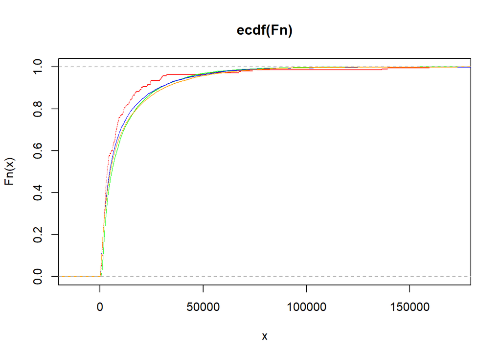

```r
Fn <- prediction_data %>% filter(size.recov > 0) %>% pull(size.recov)
ecdf_pred <- ecdf(Fn)
plot(ecdf_pred, do.points = F, col.hor = "red")
ecdf_glm <- ecdf(simul_glm %>% filter(size.recov > 0) %>% pull(size.recov))
lines(ecdf_glm, do.points = F, col.hor = "green")
ecdf_gbm <- ecdf(simul_gbm %>% filter(size.recov > 0) %>% pull(size.recov))
lines(ecdf_gbm, do.points = F, col.hor = "blue")
ecdf_xgb <- ecdf(simul_xgb %>% filter(size.recov > 0) %>% pull(size.recov))
lines(ecdf_xgb, do.points = F, col.hor = "orange")
```

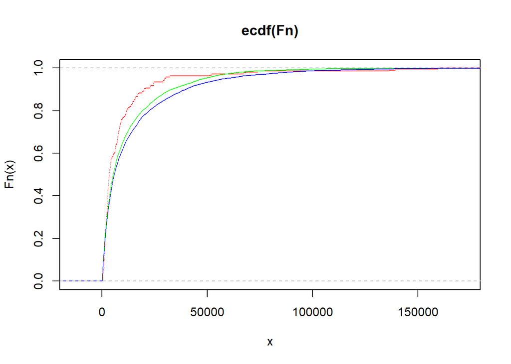

```r
Fn <- prediction_data %>% filter(size.recov > 0) %>% pull(size.recov)
ecdf_pred <- ecdf(Fn)
plot(ecdf_pred, do.points = F, col.hor = "red")
ecdf_dnn <- ecdf(simul_dnn %>% filter(size.recov > 0) %>% pull(size.recov))
lines(ecdf_dnn, do.points = F, col.hor = "green")
ecdf_dnn2 <- ecdf(simul_dnn2 %>% filter(size.recov > 0) %>% pull(size.recov))
lines(ecdf_dnn2, do.points = F, col.hor = "blue")
```

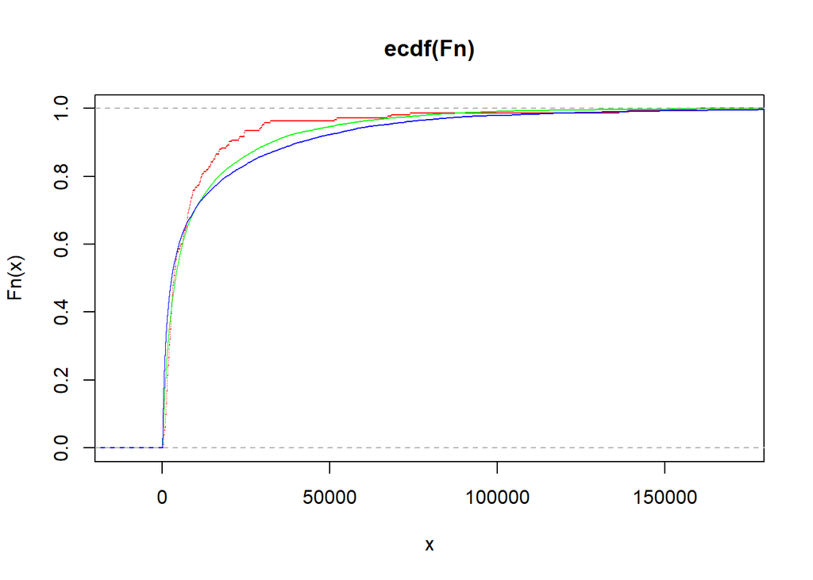

```r
Fn <- prediction_data %>% filter(size.recov > 0) %>% pull(size.recov)
ecdf_pred <- ecdf(Fn)
plot(ecdf_pred, do.points = F, col.hor = "red")
ecdf_cann <- ecdf(simul_cann %>% filter(size.recov > 0) %>% pull(size.recov))
lines(ecdf_cann, do.points = F, col.hor = "green")
ecdf_cann2 <- ecdf(simul_cann2 %>% filter(size.recov > 0) %>% pull(size.recov))
lines(ecdf_cann2, do.points = F, col.hor = "blue")
```

## References

Creveceour, Jonas, Katrien Antonio, and Jens Robben. 2021. “A Hierarchical Reserving Model for Reported Non-Life Insurance Claims.”